# Pattes de mouches: une modélisation de biophysique utilisant python scientifique

Guillaume Gay DamCB - Data analysis and modeling for Cell Biology

> **e-mail:** guillaume@damcb.com

> **github** / **freenode**: glyg

> **twitter:** @damcellbio / @elagachado

On travaille sur la mouche de vinaigre, drosophila Melanogaster:

[figure not shown]

On regarde la formation du petit pli entre les segments 4 et 5...

Vue de *très* près ça ressemble à ça:

[figure not shown]

# Le problème biologique: comment la mouche plie ses pattes?

### L'apoptose, ou les cellules kamikases

- Mort **programmée** *via* une cascade biochimique.
- Nombreuses fonctions:
  - comme la prévention du cancer
  - et la **morphogénèse**

Un exemple de *phénotype* quand il y a un défaut d'apoptose

[figure not shown]

### Dans le tissu qui donnera la patte

Pour former un pli, ~ 30 apoptoses en anneau autour de l'épithélium

[video not shown]

[Apical vue of the fold formation on a drosophila leg disk](http://vimeo.com/109897311) from [glyg](http://vimeo.com/user12210065) on [Vimeo](https://vimeo.com).

Et lorsqu'on suprime l'apoptose...

[figure not shown]

Regardons ce qu'il se passe à l'échelle cellulaire:

[figure not shown]

## Le problème biophysique

Les déformations du tissus sont dues à l'activité d'un ensemble de protéines intra et extra cellulaires.

[figure not shown]

Ces protéines forment un maillage entre les cellules, que l'on peut modéliser comme un réseau

[figure not shown]

- Minimiser localement l'énergie à chaque modification
- Équilibre des forces

Le modèle est donc basé sur la bibliothèque `graph_tool` écrite et maintenue par Tiago P. Peixoto, permettant de manipuler des graphes.

[interactive chart not shown]

Voici un exemple rapide de cette bibliothèque

```python
g = gt.price_network(3000)
pos = gt.sfdp_layout(g)

pos = gt.graph_draw(g, pos=pos, output="graph-draw-sfdp.png")
```

[figure not shown]

### Les avantages de graph-tool:

1. C'est rapide (C++ / meta-programming, openMP)
2. `PropertyMaps` interfacées aux `ndarray` de NumPy.
3. Bonnes E/S
4. Mécanisme de filtrage (*via* des `PropertyMaps` booléennes appliquées sur le graphe)
5. Bibliothèque complète d'analyse de graphes.

# Le module `leg_joint`

- Objet `Epithelium`:
  - graphe orienté, masques
  - géométrie
  - méthodes de base
- Fonctions:
  - Division cellulaire, apoptose ...
  - Optimisations
  - Représentation graphiques

```python
### Create an epithelium by instanciating the container class

eptm = lj.Epithelium(lj.data.before_apoptosis_xml(),
                     save_dir='.',
                     identifier='slides',
                     copy=True)

### Scale the tissue globaly to approach equilibrium
eptm.isotropic_relax()
```

[figure not shown]

### Un exemple: la division cellulaire

```
The vertex 913 is a cell: True
```

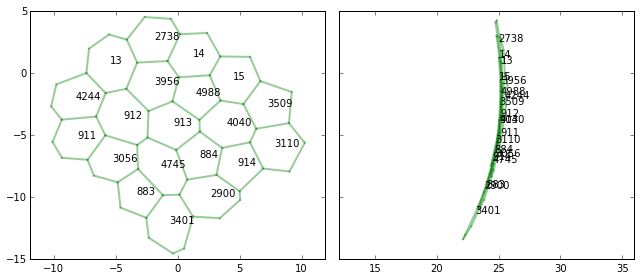

```python
### Select cell a vertex

mother_cell = eptm.graph.vertex(913)
print('The vertex {} is a cell: {}'.format(
      mother_cell, bool(eptm.is_cell_vert[mother_cell])))


### Local mask is used to work only on part of the epithelium
eptm.set_local_mask(None)
eptm.set_local_mask(mother_cell, wider=True)
fig, axes=plt.subplots(1, 2, figsize=(9, 4), sharey=True)
axes = lj.plot_2pannels(eptm,
                        cell_kwargs={'c_text':True},
                        edge_kwargs={'c':'g', 'lw':2, 'alpha':0.4},
                        axes=axes)
```

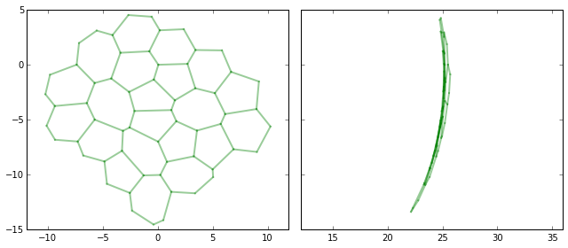

```python
septum = lj.cell_division(eptm, mother_cell, verbose=False)

### Gradient descent energy minimization (`fmin_lbfgs_b` is used)
pos0, pos1 = lj.find_energy_min(eptm)
fig, axes=plt.subplots(1, 2, figsize=(9, 4), sharey=True)
axes = lj.plot_2pannels(eptm,
                        cell_kwargs={'c_text':False},
                        edge_kwargs={'c':'g', 'lw':2, 'alpha':0.4},
                        axes=axes)
```

On choisit une cellule apoptotique

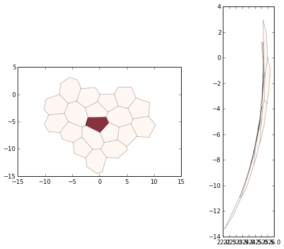

```python
fig, axes = plt.subplots(1, 2, figsize=(8, 6))

a_cell = mother_cell
eptm.set_local_mask(None)
eptm.set_local_mask(a_cell, wider=True)

ax_zs, ax_xy = show_apopto_surroundings(eptm, a_cell, axes=axes)
```

À 10 reprises, on diminue son volume d'équilibre, et on tire dessus avec une force radiale croissante

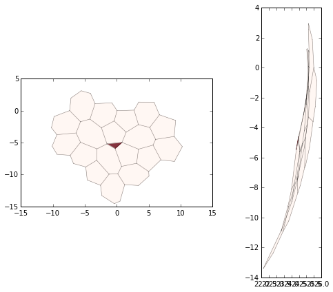

```python
fig, axes = plt.subplots(1, 2, figsize=(8, 6))

for i in range(10):
    lj.apoptosis_step(eptm, a_cell,
                      vol_reduction=0.7, ## Reduction of equilibrium volume
                      radial_tension=0.1, ## Increase in radial force
                      contractility=1.2, ## Increase in contractility for the apoptotic cell
                      )

ax_zs, ax_xy = show_apopto_surroundings(eptm, a_cell, axes)
```

Lorsqu'on fait ça 30 fois, voilà ce qu'il se passe:

[video not shown]

[Fold formation model](http://vimeo.com/107188046) from [glyg](http://vimeo.com/user12210065) on [Vimeo](https://vimeo.com).

[figure not shown]

Pas de force $\Leftrightarrow$ pas de pli:

**on confirme l'hypothèse de la nécessité d'un rôle actif de l'apoptose dans la morphogénèse**

## Reste à faire

1. Tests unitaires & intégration continue
2. Rendu dynamique 3D avec Blender (en cours)
3. Gros réusinage du code:
   - description basée sur des évennements
   - optimiser (y'a du boulot...)

## Et ensuite

1. Généraliser la géométrie, surface basale
2. Plateforme de modélisation de tissus "multi-physique"

### Les biologistes

- Mélanie Gettings
- Bruno Monier
- Sonia Shott
- **Magali Suzanne**

### L'autre physicien

- Thomas Mangeat